# Git Installation Guide for Students

Author

Professor Alex

Published

May 10, 2025

This guide will walk you through installing **Git** on your Windows computer and setting it up to work with **GitHub**. Follow these steps carefully!

## 1 Why Learn Git and Version Control?

Before we dive into the installation process, let’s understand why Git is such an important tool for students and professionals alike.

### 1.1 What is Git?

Git is a **version control system** - a tool that helps you track changes to your files over time. Think of it as a super-powered “save” button that:

- Records a complete history of changes to your files
- Allows you to go back in time to any previous version
- Helps you collaborate with others without overwriting each other’s work
- Keeps your work organized and backed up

### 1.2 Why Should You Care About Version Control?

As a student, you might wonder why you need version control. Here are some practical reasons:

- **Never lose your work**: Have you ever accidentally deleted part of an assignment and couldn’t get it back? With Git, you can restore any previous version.
- **Track your progress**: See how your project evolved from beginning to end, which is great for learning and reflection.
- **Experiment freely**: Try new approaches without fear. If something doesn’t work out, you can easily revert to a working version.
- **Collaborate effectively**: Work on group projects without the chaos of emailing files back and forth or dealing with conflicting changes.
- **Document AI contributions**: When using tools like GitHub Copilot or ChatGPT to help with your code, Git lets you track which parts were AI-generated versus your own work when copying and pasting.

### 1.3 How Git Works in Practice

Here’s a simple workflow to understand how you’ll use Git:

1. **Create or modify files** for your project (e.g., writing code, creating documents)
2. **Save changes** to Git (this is called “committing”)
3. **Push your work** to GitHub (an online service) to back it up
4. **Pull updates** when working on a different computer or with teammates

Think of it like this:

- Your computer has a complete copy of your project
- GitHub has another copy stored safely online
- Git tracks the differences as you make changes
- You use simple commands to keep everything in sync

### 1.4 Benefits for Beginners

Even if you’re just starting out:

- **Build good habits early**: Learning Git now will prepare you for future academic and professional work
- **Organize your learning**: Keep track of exercises, assignments, and projects in one place
- **Recover from mistakes**: Accidentally deleted something important? No problem - Git can help you get it back
- **Show your work**: Build a portfolio of your projects that you can share with teachers or future employers

Now that you understand why Git is valuable, let’s get it installed on your computer.

## 2 Download Git

1. Open your web browser and go to the official Git website: https://git-scm.com/download/win
2. On the download page, look for “Click here to download” under the text that says “(2.49.0) x64 version of Git for Windows”
3. Click on that download link to start downloading the installer

[figure not shown]

Git: Download for Windows

## 3 Install Git

Run the downloaded installer and follow these steps:

1. If you see a security warning, click **Run** or **Yes** to continue
2. On the license screen, click **Next**
3. Choose the installation location (the default is fine) and click **Next**
4. On the Select Components screen, leave the defaults and click **Next**
   - Make sure “Windows Explorer integration” is checked
   - Make sure “Git Bash Here” is checked
   - Make sure “Git GUI Here” is checked

[figure not shown]

Git: Components

5. Choose the default editor and click **Next**
   - Select *Use Visual Studio as Git’s default editor* if you have it installed
   - Otherwise, select *Use Notepad* or any other text editor you prefer
6. For “Adjusting the name of the initial branch in new repositories”:
   - Select “Override the default branch name for new repositories”
   - Fill in the name of the default branch (e.g., `main`).
   - Click **Next**
7. For “Adjusting your PATH environment”, select **Git from the command line and also from 3rd-party software** (the middle option) and click **Next**
8. For “Choosing the SSH executable”, select **Use bundled OpenSSH** and click **Next**
9. For “Choosing HTTPS transport backend”, select **Use the OpenSSL library** and click **Next**
10. For “Configuring the line ending conversions”, select **Checkout Windows-style, commit Unix-style line endings** and click **Next**
11. For “Configuring the terminal emulator”, select **Use MinTTY** and click **Next**
12. For “Choose the default behavior of `git pull`”, select **Fast-forward or merge** and click **Next**
13. For “Choose a credential helper”, select **Git Credential Manager** and click **Next**
14. For “Configuring extra options”, leave the defaults and click **Next**
15. For “Configuring experimental options”, leave unchecked and click **Install**
16. Wait for the installation to complete, then click **Finish**

## 4 Verify Installation

Let’s make sure Git was installed correctly:

1. Press the Windows key, type “cmd” and open Command Prompt
2. Type the following command and press Enter:

```powershell
git --version
```

3. You should see something like `git version 2.49.0.windows.1` (the numbers might be different)

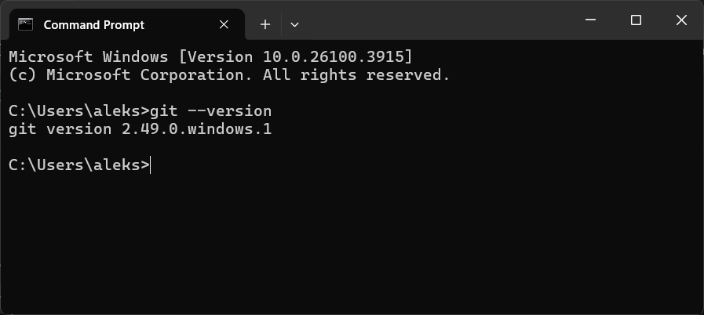

Git: Verify Installation

## 5 Configure Git with Your Name and Email

Now we need to tell Git who you are. This information will be included with your changes:

1. Open Command Prompt if it’s not already open (Windows key, type “cmd”, open Command Prompt)
2. Run these commands, replacing the example information with your own:

```powershell
git config --global user.name "Your Name"
```

```powershell
git config --global user.email "your.email@example.com"
```

**Warning**

Use the same email that you used to create your GitHub account

3. Verify your settings with:

```powershell
git config --global user.name
```

```powershell
git config --global user.email
```

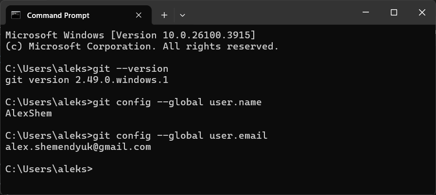

Git: Verify Configuration

## 6 Using Git with GitHub

Now that Git is installed and configured, let’s connect to GitHub and learn how to use basic Git commands.

### 6.1 Cloning a Repository (Your First GitHub Connection)

Let’s start by cloning (downloading) a repository from GitHub. This will also set up your connection to GitHub:

1. Go to the GitHub repository in your browser
2. Click the green **Code** button
3. Make sure HTTPS is selected
4. Copy the URL
5. Open Command Prompt (or VS Code terminal)
6. Navigate to the folder where you want to download the repository using the `cd` command:

```powershell
cd C:\Users\YourUsername\Documents\GitHub
```

7. Clone the repository by typing:

```powershell
git clone https://github.com/username/repository.git
```

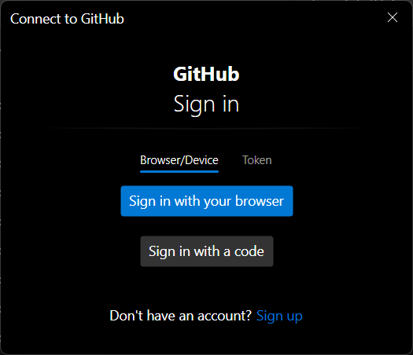

Git: Cloning Authentication Pop-Up

**Note**

If you’ve previously authenticated with GitHub, you might not be prompted to log in again when cloning. This means Git Credential Manager is already working correctly and using your stored credentials.

### 6.2 The Magic of Git Credential Manager

You only need to sign in **once** because Git Credential Manager (which we installed with Git) will:

- Store your authentication details securely in Windows Credential Manager
- Use these stored credentials for future GitHub operations
- No more typing your password each time!

### 6.3 Working with Files

After cloning a repository and making changes to files, here’s how to save and upload your changes:

1. Check which files you’ve modified:

```powershell
git status
```

2. Add all changed files to be committed:

```powershell
git add .
```

3. Commit your changes with a message:

```powershell
git commit -m "Describe what you changed"
```

4. Push your changes to GitHub:

```powershell
git push
```

**Tip**

When you push for the first time, Git might ask you to authenticate if it hasn’t already happened during cloning.

## 7 Troubleshooting

If you encounter any issues:

- Make sure you’re using your GitHub username correctly
- If Git asks for your password and doesn’t open a browser, make sure you enter your GitHub account password
- If you see an error about authentication, try restarting your computer and trying again
- Check that you have a working internet connection
- If you’re still having trouble, ask your teacher for help

## 8 Next Steps

Now that you have Git installed and configured, you’re ready to start using it for your projects!

| Command | Description |
| --- | --- |
| `git clone` | Download a repository |
| `git add` | Stage changes |
| `git commit` | Save changes locally |
| `git push` | Upload changes to GitHub |

**Tip**

Happy coding!